## Sampling a zero mean GMRF with block-circulant precision

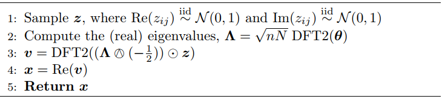

[Henrique Ap. Laureano](http://www.github.com/mynameislaure)  
email: henrique.laureano@kaust.edu.sa

```
## [1] "Mon Jul 31 10:50:09 2017"
```

### First, generating a block-circulant precision matrix

```r
options(width=125)
cm <- function(x) { # cm: circulant matrix
  n <- length(x)
  suppressWarnings(
    matrix(x[matrix(1:n, n+1, n+1, byrow = TRUE)[c(1, n:2), 1:n]], n, n)
  )
} ; cm(letters[1:4])
```

```
##      [,1] [,2] [,3] [,4]
## [1,] "a"  "b"  "c"  "d"
## [2,] "d"  "a"  "b"  "c"
## [3,] "c"  "d"  "a"  "b"
## [4,] "b"  "c"  "d"  "a"
```

```r
cols <- function(ms, n) { # ms: matrices (list of)
  if (n == 0) return(ms)
  c( tail(ms, n), head(ms, -n) )
}
rcols <- function(n, ms) do.call(rbind, cols(ms, n))
bcm <- function(ms) { # bcm: Block-Circulant Matrix
  n <- length(ms)
  do.call( cbind, lapply(0:(n-1), rcols, ms) )
}
### Three different circulating matrix of dimension 3 x 3
( ms <- list( cm(c(5, 2, 2)), cm(c(2, 0, 0)), cm(1:3) ) )
```

```
## [[1]]
##      [,1] [,2] [,3]
## [1,]    5    2    2
## [2,]    2    5    2
## [3,]    2    2    5
##
## [[2]]
##      [,1] [,2] [,3]
## [1,]    2    0    0
## [2,]    0    2    0
## [3,]    0    0    2
##
## [[3]]
##      [,1] [,2] [,3]
## [1,]    1    2    3
## [2,]    3    1    2
## [3,]    2    3    1
```

```r
( th <- bcm(ms) )
```

```
##       [,1] [,2] [,3] [,4] [,5] [,6] [,7] [,8] [,9]
##  [1,]    5    2    2    1    2    3    2    0    0
##  [2,]    2    5    2    3    1    2    0    2    0
##  [3,]    2    2    5    2    3    1    0    0    2
##  [4,]    2    0    0    5    2    2    1    2    3
##  [5,]    0    2    0    2    5    2    3    1    2
##  [6,]    0    0    2    2    2    5    2    3    1
##  [7,]    1    2    3    2    0    0    5    2    2
##  [8,]    3    1    2    0    2    0    2    5    2
##  [9,]    2    3    1    0    0    2    2    2    5
```

```r
chol(th) # Showing that the resulting matrix is SPD
```

```
##           [,1]      [,2]      [,3]      [,4]       [,5]       [,6]        [,7]       [,8]       [,9]
##  [1,] 2.236068 0.8944272 0.8944272 0.4472136 0.89442719  1.3416408  0.89442719  0.0000000 0.00000000
##  [2,] 0.000000 2.0493902 0.5855400 1.2686701 0.09759001  0.3903600 -0.39036003  0.9759001 0.00000000
##  [3,] 0.000000 0.0000000 1.9639610 0.4364358 1.09108945 -0.2182179 -0.29095719 -0.2909572 1.01835015
##  [4,] 0.000000 0.0000000 0.0000000 1.7320508 0.57735027  0.5773503  0.70565033  0.5132002 1.47545069
##  [5,] 0.000000 0.0000000 0.0000000 0.0000000 1.63299316  0.4082483  1.31546671  0.5670115 0.02268046
##  [6,] 0.000000 0.0000000 0.0000000 0.0000000 0.00000000  1.5811388 -0.03513642  1.2824793 0.22838672
##  [7,] 0.000000 0.0000000 0.0000000 0.0000000 0.00000000  0.0000000  1.31656118  0.9367839 0.93678391
##  [8,] 0.000000 0.0000000 0.0000000 0.0000000 0.00000000  0.0000000  0.00000000  0.9250780 0.38458297
##  [9,] 0.000000 0.0000000 0.0000000 0.0000000 0.00000000  0.0000000  0.00000000  0.0000000 0.84134723
```

### Implementation of the algorithm steps:

> 1: Sample $\mathbf{z}$, where ${\rm Re}(z_{ij}) \overset{{\rm iid}}{\sim} N(0, 1)$ and ${\rm Im}(z_{ij}) \overset{{\rm iid}}{\sim} N(0, 1)$

```r
round(z <- matrix(rnorm(nrow(th)) + rnorm(nrow(th)) * 1i
                  , nrow = nrow(th)
                  , ncol = ncol(th)), 1)
```

```
##            [,1]      [,2]      [,3]      [,4]      [,5]      [,6]      [,7]      [,8]      [,9]
##  [1,] -0.5-1.2i -0.5-1.2i -0.5-1.2i -0.5-1.2i -0.5-1.2i -0.5-1.2i -0.5-1.2i -0.5-1.2i -0.5-1.2i
##  [2,]  0.1-0.9i  0.1-0.9i  0.1-0.9i  0.1-0.9i  0.1-0.9i  0.1-0.9i  0.1-0.9i  0.1-0.9i  0.1-0.9i
##  [3,]  1.1-0.1i  1.1-0.1i  1.1-0.1i  1.1-0.1i  1.1-0.1i  1.1-0.1i  1.1-0.1i  1.1-0.1i  1.1-0.1i
##  [4,]  0.2-1.2i  0.2-1.2i  0.2-1.2i  0.2-1.2i  0.2-1.2i  0.2-1.2i  0.2-1.2i  0.2-1.2i  0.2-1.2i
##  [5,] -0.2+0.0i -0.2+0.0i -0.2+0.0i -0.2+0.0i -0.2+0.0i -0.2+0.0i -0.2+0.0i -0.2+0.0i -0.2+0.0i
##  [6,] -0.2-1.6i -0.2-1.6i -0.2-1.6i -0.2-1.6i -0.2-1.6i -0.2-1.6i -0.2-1.6i -0.2-1.6i -0.2-1.6i
##  [7,] -0.7-0.3i -0.7-0.3i -0.7-0.3i -0.7-0.3i -0.7-0.3i -0.7-0.3i -0.7-0.3i -0.7-0.3i -0.7-0.3i
##  [8,] -1.7-1.6i -1.7-1.6i -1.7-1.6i -1.7-1.6i -1.7-1.6i -1.7-1.6i -1.7-1.6i -1.7-1.6i -1.7-1.6i
##  [9,]  0.1+1.8i  0.1+1.8i  0.1+1.8i  0.1+1.8i  0.1+1.8i  0.1+1.8i  0.1+1.8i  0.1+1.8i  0.1+1.8i
```

> 2: Compute the (real) eigenvalues, $\mathbf{\Lambda} = \sqrt{n\cdot N}{\rm DFT2}(\theta)$

On what

- $n$ is the number of **rows** in the matrix $\theta$;
- $N$ is the number of **columns** in the matriz $\theta$;
- $\theta$ I **assumed** it is the block-circulant precision matrix;
- DFT2 (**two-dimensional discrete Fourier transform matrix**):
  - matrix with elements:

$$\frac{1}{nN} \sum_{{i}'=0}^{n-1} \sum_{{j}'=0}^{N-1} \theta_{{i}'{j}'}
\exp \bigg( -2 \pi {\rm i} (\frac{i{i}'}{n} + \frac{j{j}'}{N})
\bigg), \quad {\rm i} = \sqrt{-1}.$$

*By steps, for understanding:*

For a given $i$ e $j$, 1 and 1, for example, we calculated $\sum_{{i}'=0}^{n-1} \sum_{{j}'=0}^{N-1} \theta_{{i}'{j}'}$ with

```r
# with the following line of code we select all the necessary elements of
# the matrix mx and order them in a way in which the correct
# multiplication is done with the exponential of the next part of the
# equation
c(t( mx[1:(n-1), 1:(N-1)] )) # in sum()
```

For a given $i$ e $j$, 1 and 1, for example, we calculated $\sum_{{i}'=0}^{n-1} \sum_{{j}'=0}^{N-1} \exp \bigg( -2 \pi {\rm i} (\frac{i{i}'}{n} + \frac{j{j}'}{N}) \bigg)$ with

```r
# in sum()
exp(-2 * pi * 1i * apply(expand.grid(i*1:(n-1)/n, j*1:(N-1)/N), 1, sum))
```

$\square$

Ok, now, the complete implementation:

```r
dft2 <- function(mx) {
  n <- dim(mx)[1]
  N <- dim(mx)[2]
  mx.dft2 <- matrix(NA, nrow = n, ncol = N)
  for (i in 1:n) {
    for (j in 1:N) {
      mx.dft2[i, j] <- ( 1/sqrt(n*N) ) *
        sum( c(t( mx[1:(n-1), 1:(N-1)] )) *
               exp( -2 * pi * 1i *
                      apply(expand.grid(i*1:(n-1)/n, j*1:(N-1)/N), 1, sum)
               ) )
    } }
  return(mx.dft2) } ; n <- dim(th)[1] ; N <- dim(th)[2]

round( lambda <- sqrt(nrow(th) * ncol(th)) * dft2(th), 1 )
```

```
##              [,1]        [,2]       [,3]        [,4]        [,5]       [,6]        [,7]        [,8]       [,9]
##  [1,]  -3.1- 1.9i   7.1+14.6i  -5.9+1.0i  -6.5+ 0.6i   5.1- 5.2i  -5.9-0.7i  -8.2+ 4.3i  36.8-12.6i -19.4+0.1i
##  [2,] -19.0- 4.8i  -0.3- 3.0i   2.0+2.1i  -3.8+12.7i   1.5+ 0.7i   2.0+0.3i  24.3-12.6i   4.8+ 3.3i -11.5+1.2i
##  [3,]   0.8- 2.9i  -4.3- 5.0i  -2.0+0.0i  -2.5- 0.4i  -2.5- 1.3i  29.5+6.1i  -4.3+ 3.3i   0.8+ 1.2i -15.5-0.9i
##  [4,]   0.7- 3.6i   7.9- 4.8i  -2.1-0.6i  -2.6- 1.0i  27.3+18.3i  -2.1-2.4i  -4.4+ 2.7i  -9.3- 7.1i -15.6-1.5i
##  [5,]  -9.3+ 7.1i  -4.4- 2.7i  -2.1+2.4i  27.3-18.3i  -2.6+ 1.0i  -2.1+0.6i   7.9+ 4.8i   0.7+ 3.6i -15.6+1.5i
##  [6,]   0.8- 1.2i  -4.3- 3.3i  29.5-6.1i  -2.5+ 1.3i  -2.5+ 0.4i  -2.0+0.0i  -4.3+ 5.0i   0.8+ 2.9i -15.5+0.9i
##  [7,]   4.8- 3.3i  24.3+12.6i   2.0-0.3i   1.5- 0.7i  -3.8-12.7i   2.0-2.1i  -0.3+ 3.0i -19.0+ 4.8i -11.5-1.2i
##  [8,]  36.8+12.6i  -8.2- 4.3i  -5.9+0.7i   5.1+ 5.2i  -6.5- 0.6i  -5.9-1.0i   7.1-14.6i  -3.1+ 1.9i -19.4-0.1i
##  [9,] -12.7- 2.0i -17.8- 4.2i -15.5+0.9i -16.0+ 0.5i -16.0- 0.5i -15.5-0.9i -17.8+ 4.2i -12.7+ 2.0i 124.0+0.0i
```

### Problem / doubt

**Via spectral decomposition, for example, we should also obtain these eigenvalues, $\mathbf{\Lambda}$, but this is not what happens:**

```r
round(eigen(th)$values, 1)
```

```
## [1] 17.0+0.0i  5.0+3.5i  5.0-3.5i  3.5+2.6i  3.5-2.6i  2.0+3.5i  2.0-3.5i  3.5+0.9i  3.5-0.9i
```

**The “real” eigenvalues, written in this step of the algorithm also caused me doubt. What does that mean? It’s not just to get the real part of $\mathbf{\Lambda}$, in this way step 3 fails.**

**Looking to the implementation, I don’t see anything wrong (wrong implemented), and you?**

> 3: $\boldsymbol{\upsilon}= {\rm DFT2}((\mathbf{\Lambda}\text{elementwisepower}(-\frac{1}{2})) \odot\mathbf{z})$

```r
round(upsilon <- dft2( lambda**(-1/2)*z ), 1)
```

```
##            [,1]      [,2]      [,3]      [,4]      [,5]      [,6]      [,7]      [,8]      [,9]
##  [1,] -0.1+0.2i -0.5+0.0i  0.1-0.5i -0.1-0.2i -0.4+0.4i  0.5-0.6i -0.2-0.1i  0.1+0.9i  0.4-0.2i
##  [2,]  0.2-0.7i -0.2+0.2i  0.1-0.1i  0.6+0.0i  0.2+0.9i  0.0+0.3i  0.4+0.1i -0.5-0.1i -0.7-0.7i
##  [3,] -0.2+0.1i -0.1-0.3i -0.1-0.1i -0.2+0.1i -0.1-0.6i  0.0+0.0i  0.2+0.2i  0.1+0.0i  0.4+0.5i
##  [4,]  0.3+0.0i  0.4+0.0i  0.2+0.8i -0.3-0.1i  0.4+0.1i -0.5-0.2i -0.6-0.5i  0.3-0.6i -0.2+0.4i
##  [5,]  0.3+0.3i  0.2-0.2i -0.1+0.4i  0.2+0.2i  0.0+0.1i -0.3-0.3i -0.3-0.2i  0.3-0.2i -0.4-0.2i
##  [6,] -0.2+0.4i  0.2+0.1i  0.2+0.0i -0.4+0.2i -0.1-0.5i  0.1+0.2i  0.0+0.3i -0.2-0.7i  0.3+0.0i
##  [7,]  0.1+0.2i  0.3+0.1i -0.7-0.2i -0.5-0.8i  0.1-0.5i -0.2+0.2i  0.2-0.4i  0.5+0.2i  0.3+1.1i
##  [8,] -0.1+0.4i -0.2-0.6i  0.0-0.6i -0.2+0.4i  0.5+0.3i  0.2-0.2i -0.2+0.5i  0.1-0.2i  0.0+0.0i
##  [9,] -0.3-0.9i  0.0+0.7i  0.3+0.2i  0.9+0.2i -0.8-0.1i  0.1+0.4i  0.6+0.0i -0.8+0.6i  0.0-1.0i
```

> 4: $\mathbf{x} = {\rm Re}(\boldsymbol{\upsilon})$

```r
x <- Re(upsilon)
```

> 5: Return $\mathbf{x}$

```r
round(x, 4)
```

```
##          [,1]    [,2]    [,3]    [,4]    [,5]    [,6]    [,7]    [,8]    [,9]
##  [1,] -0.0666 -0.5033  0.0911 -0.0520 -0.3605  0.5393 -0.2205  0.1243  0.4484
##  [2,]  0.1966 -0.1977  0.1042  0.6213  0.2273 -0.0449  0.3624 -0.5292 -0.7399
##  [3,] -0.1978 -0.1319 -0.0919 -0.1983 -0.0758  0.0333  0.1641  0.1340  0.3644
##  [4,]  0.2904  0.3964  0.1630 -0.3311  0.3637 -0.4703 -0.5530  0.3491 -0.2081
##  [5,]  0.3150  0.1734 -0.0723  0.2306  0.0125 -0.2525 -0.3178  0.2763 -0.3653
##  [6,] -0.1510  0.2461  0.2498 -0.4086 -0.0673  0.1275 -0.0474 -0.2126  0.2635
##  [7,]  0.0736  0.2579 -0.7367 -0.4987  0.1475 -0.2293  0.1848  0.5329  0.2678
##  [8,] -0.1384 -0.2011 -0.0268 -0.2220  0.5211  0.1536 -0.1811  0.1004 -0.0057
##  [9,] -0.3217 -0.0397  0.3196  0.8588 -0.7685  0.1432  0.6085 -0.7752 -0.0251
```

$\blacksquare$